# SINAICA Data.

```python
import os, gzip, json, re, stan, dplython, asyncio, nest_asyncio
#nest_asyncio.apply()
import warnings
from matplotlib import pyplot as plt
warnings.filterwarnings("ignore", category=DeprecationWarning)
from dplython import (DplyFrame, X, diamonds, select, sift,
  sample_n, sample_frac, head, arrange, mutate, group_by,
  summarize, DelayFunction, dfilter)
import seaborn as sns
from plotnine import *
from sklearn.linear_model import LinearRegression, Lasso
from sklearn.model_selection import train_test_split
from sklearn.metrics import (mean_squared_error,
                             r2_score,
                             mean_absolute_error)
import pandas as pd
import numpy as np
from IPython.display import display, Markdown, update_display
```

```python
base_dir = "data/sinaica2/"
data_dir = os.path.join(
    os.getcwd(),
    base_dir
)

#df = pd.read_pickle("data/airdata/air.pickle")

display(Markdown(f"Listing data files from: {data_dir}..."))

generator = (file for file in os.listdir(data_dir)
             if (re.match(r"Datos SINAICA - [-A-ZáéíóúÁÉÍÓÚa-z0-9. ]{30,80}\.csv", file) is not None))
num_files = len([j for (j, _) in enumerate(generator)]) + 1
generator.close()

generator = (file for file in os.listdir(data_dir)
             if (re.match(r"Datos SINAICA - [-A-ZáéíóúÁÉÍÓÚa-z0-9. ]{30,80}\.csv", file) is not None))
sinaica = pd.read_pickle("data/sinaica.pickle")

display(Markdown(""), display_id="read_sinaica")

for (j, file_csv) in enumerate(generator):
    ##display(Markdown(f"{j+1}. File \"{file_csv}\""))
    update_display(Markdown(f">Reading file {j+1} of {num_files} \"{file_csv}\""), display_id="read_sinaica")
    ##print("%d out of %d"%(j+1, num_files), end="")

    try:
        station, sensor = re.match(
            r"Datos SINAICA - ([A-ZáéíóúÁÉÍÓÚa-z. ]{3,20}) - ([A-Z0-9a-z.]+) - [-0-9 ]+\.csv",
             file_csv).groups()
        #display(Markdown(f"   * {station}, {sensor}"))
        df2 = pd.read_csv(os.path.join(data_dir, file_csv))
        df2 = df2.assign(Estacion=station)
        sinaica = pd.concat([sinaica, df2])
        #display(df2.head(3))
        sinaica = sinaica.sort_values(by=["Fecha", "Estacion", "Parámetro"])
        sinaica["Hora"] = sinaica[["Hora"]].replace("- .*$", "", regex=True)
        ##print(sinaica["Fecha"])
        sinaica["Fecha"] = pd.to_datetime(sinaica["Fecha"])
        ##sinaica["Fecha"] = pd.to_datetime(sinaica["Fecha"] + " " + sinaica["Hora"])
        sinaica.drop("Hora", axis=1, inplace=True)
        sinaica = sinaica[(sinaica["Fecha"] >= "2021-01-01")].copy()
        ##display(Markdown(f"Done reading {j+1} files!"))
        #display(pd.concat([sinaica.head(5), sinaica.tail(5)]))
    except Exception as e:
        print(f"\nError while reading file {file_csv}", type(e))
        raise e
        generator.close()
update_display(Markdown(f"Done!"), display_id="read_sinaica")
generator.close()
```

Listing data files from: /home/jaa6766/Documents/jorge3a/itam/deeplearning/dlfinal/data/sinaica2/...

Done!

```python
sinaica
```

|  | Parámetro | Fecha | Valor | Unidad | Estacion |
| --- | --- | --- | --- | --- | --- |
| 1 | CO | 2021-01-01 | 0.600 | ppm | Camarones |
| 1 | NO | 2021-01-01 | 0.006 | ppm | Camarones |
| 1 | NO2 | 2021-01-01 | 0.029 | ppm | Camarones |
| 1 | NOx | 2021-01-01 | 0.034 | ppm | Camarones |
| 1 | O3 | 2021-01-01 | 0.011 | ppm | Camarones |
| ... | ... | ... | ... | ... | ... |
| 34 | SO2 | 2021-10-08 | 0.002 | ppm | Merced |
| 35 | SO2 | 2021-10-08 | 0.001 | ppm | Merced |
| 36 | SO2 | 2021-10-08 | 0.001 | ppm | Merced |
| 37 | SO2 | 2021-10-08 | 0.000 | ppm | Merced |
| 38 | SO2 | 2021-10-08 | 0.001 | ppm | Merced |

196289 rows × 5 columns

### Nearby Air Quality Monitoring Stations

Here you may find the most proximate stations to "Camarones" which is the closest one to our sensor.

[figure not shown]

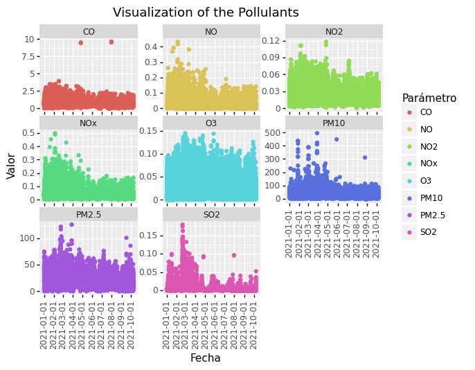

```python
(
    ggplot(sinaica) +
    geom_point(aes(x="Fecha", y="Valor", color="Parámetro")) +
    facet_wrap("Parámetro", scales="free") +
    labs(title="Visualization of the Pollulants") +
    theme(axis_text_x=element_text(angle=90),
          subplots_adjust={'wspace': 0.25, 'hspace': 0.25}
         )
)
```

### Camarones Air Quality Monitoring Station

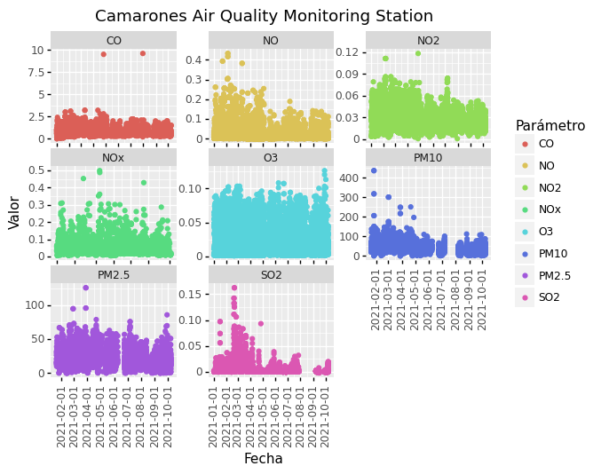

```python
(
    ggplot(sinaica[(sinaica["Estacion"] == "Camarones")]) +
    geom_point(aes(x="Fecha", y="Valor", color="Parámetro")) +
    facet_wrap("Parámetro", scales="free") +
    labs(title="Camarones Air Quality Monitoring Station") +
    theme(axis_text_x=element_text(angle=90),
          subplots_adjust={'wspace': 0.25, 'hspace': 0.25}
         )
)
```

```python
sinaica.to_pickle("data/sinaica/sinaica.pickle")
```

## Imputation: Missing Data from the Air Quality Monitoring Stations.

Some of the missisng observatinos are caused by maintenance on the monitoring systems. So we could try to fill out the missing data with nearby government sesnsors. Then we propose to evaluate how the imputations work.

```python
dsinaica = DplyFrame(sinaica)
dsinaica2 = (
    dsinaica.
    pivot_table(index=["Fecha", ], columns=["Estacion", "Parámetro"], values="Valor",
               )
)
dsinaica2.columns = ["_".join(x).strip() for x in dsinaica2.columns]
dsinaica2.insert(0, "Fecha", dsinaica2.index)
dsinaica2.reset_index(drop=True, inplace=True)
dsinaica2.to_pickle("data/sinaica2/dsinaica.pickle")
dsinaica = DplyFrame(pd.read_pickle("data/sinaica2/dsinaica.pickle"))
dsinaica
```

|  | Fecha | Camarones_CO | Camarones_NO | Camarones_NO2 | Camarones_NOx | Camarones_O3 | Camarones_PM10 | Camarones_PM2.5 | Camarones_SO2 | FES Acatlán_CO | ... | Miguel Hidalgo_O3 | Miguel Hidalgo_SO2 | Tlalnepantla_CO | Tlalnepantla_NO | Tlalnepantla_NO2 | Tlalnepantla_NOx | Tlalnepantla_O3 | Tlalnepantla_PM10 | Tlalnepantla_PM2.5 | Tlalnepantla_SO2 |
| --- | --- | --- | --- | --- | --- | --- | --- | --- | --- | --- | --- | --- | --- | --- | --- | --- | --- | --- | --- | --- | --- |
| 0 | 2021-01-01 00:00:00 | 0.600000 | 0.006000 | 0.029000 | 0.034 | 0.011000 | NaN | NaN | 0.002000 | 0.400000 | ... | 0.009 | 0.003 | 0.6 | NaN | 0.030 | 0.034 | 0.012 | 37.0 | 19.0 | 0.002 |
| 1 | 2021-01-01 01:00:00 | 1.000000 | 0.021000 | 0.038000 | 0.059 | 0.002000 | NaN | NaN | 0.002000 | 0.600000 | ... | 0.006 | 0.003 | 0.6 | NaN | 0.026 | 0.029 | 0.013 | 42.0 | 29.0 | 0.003 |
| 2 | 2021-01-01 02:00:00 | 0.800000 | 0.013000 | 0.035000 | 0.049 | 0.003000 | NaN | NaN | 0.001000 | 0.900000 | ... | 0.003 | 0.002 | 0.7 | NaN | 0.032 | 0.036 | 0.006 | 58.0 | 43.0 | 0.002 |
| 3 | 2021-01-01 03:00:00 | 1.000000 | 0.031000 | 0.034000 | 0.065 | 0.002000 | NaN | NaN | 0.001000 | 0.800000 | ... | 0.004 | 0.002 | 0.7 | NaN | 0.033 | 0.039 | 0.004 | 59.0 | 41.0 | 0.002 |
| 4 | 2021-01-01 04:00:00 | 0.600000 | 0.005000 | 0.029000 | 0.034 | 0.005000 | NaN | NaN | 0.001000 | 1.000000 | ... | 0.006 | 0.002 | 0.7 | NaN | 0.032 | 0.038 | 0.004 | 64.0 | 46.0 | 0.002 |
| ... | ... | ... | ... | ... | ... | ... | ... | ... | ... | ... | ... | ... | ... | ... | ... | ... | ... | ... | ... | ... | ... |
| 2347 | 2021-10-04 00:00:00 | 0.441667 | 0.008292 | 0.015833 | NaN | 0.017167 | 22.173913 | 10.952381 | 0.000125 | 0.315000 | ... | NaN | NaN | NaN | NaN | NaN | NaN | NaN | NaN | NaN | NaN |
| 2348 | 2021-10-05 00:00:00 | 0.490000 | 0.010000 | 0.017000 | NaN | 0.013947 | 22.142857 | 8.736842 | 0.000000 | 0.466667 | ... | NaN | NaN | NaN | NaN | NaN | NaN | NaN | NaN | NaN | NaN |
| 2349 | 2021-10-06 00:00:00 | 0.542857 | 0.007571 | 0.022571 | NaN | 0.014333 | 25.150000 | 10.150000 | 0.000000 | 0.347619 | ... | NaN | NaN | NaN | NaN | NaN | NaN | NaN | NaN | NaN | NaN |
| 2350 | 2021-10-07 00:00:00 | 0.582609 | 0.011565 | 0.023130 | NaN | 0.021304 | 33.500000 | 15.428571 | 0.001783 | 0.447826 | ... | NaN | NaN | NaN | NaN | NaN | NaN | NaN | NaN | NaN | NaN |
| 2351 | 2021-10-08 00:00:00 | 0.738889 | 0.023778 | 0.026778 | NaN | 0.019667 | 41.266667 | 18.800000 | 0.010500 | 0.566667 | ... | NaN | NaN | NaN | NaN | NaN | NaN | NaN | NaN | NaN | NaN |

2352 rows × 45 columns

```python
dsinaica[dsinaica.isna().any(axis=1)]
```

|  | Fecha | Camarones_CO | Camarones_NO | Camarones_NO2 | Camarones_NOx | Camarones_O3 | Camarones_PM10 | Camarones_PM2.5 | Camarones_SO2 | FES Acatlán_CO | ... | Miguel Hidalgo_O3 | Miguel Hidalgo_SO2 | Tlalnepantla_CO | Tlalnepantla_NO | Tlalnepantla_NO2 | Tlalnepantla_NOx | Tlalnepantla_O3 | Tlalnepantla_PM10 | Tlalnepantla_PM2.5 | Tlalnepantla_SO2 |
| --- | --- | --- | --- | --- | --- | --- | --- | --- | --- | --- | --- | --- | --- | --- | --- | --- | --- | --- | --- | --- | --- |
| 0 | 2021-01-01 00:00:00 | 0.600000 | 0.006000 | 0.029000 | 0.034 | 0.011000 | NaN | NaN | 0.002000 | 0.400000 | ... | 0.009 | 0.003 | 0.6 | NaN | 0.030 | 0.034 | 0.012 | 37.0 | 19.0 | 0.002 |
| 1 | 2021-01-01 01:00:00 | 1.000000 | 0.021000 | 0.038000 | 0.059 | 0.002000 | NaN | NaN | 0.002000 | 0.600000 | ... | 0.006 | 0.003 | 0.6 | NaN | 0.026 | 0.029 | 0.013 | 42.0 | 29.0 | 0.003 |
| 2 | 2021-01-01 02:00:00 | 0.800000 | 0.013000 | 0.035000 | 0.049 | 0.003000 | NaN | NaN | 0.001000 | 0.900000 | ... | 0.003 | 0.002 | 0.7 | NaN | 0.032 | 0.036 | 0.006 | 58.0 | 43.0 | 0.002 |
| 3 | 2021-01-01 03:00:00 | 1.000000 | 0.031000 | 0.034000 | 0.065 | 0.002000 | NaN | NaN | 0.001000 | 0.800000 | ... | 0.004 | 0.002 | 0.7 | NaN | 0.033 | 0.039 | 0.004 | 59.0 | 41.0 | 0.002 |
| 4 | 2021-01-01 04:00:00 | 0.600000 | 0.005000 | 0.029000 | 0.034 | 0.005000 | NaN | NaN | 0.001000 | 1.000000 | ... | 0.006 | 0.002 | 0.7 | NaN | 0.032 | 0.038 | 0.004 | 64.0 | 46.0 | 0.002 |
| ... | ... | ... | ... | ... | ... | ... | ... | ... | ... | ... | ... | ... | ... | ... | ... | ... | ... | ... | ... | ... | ... |
| 2347 | 2021-10-04 00:00:00 | 0.441667 | 0.008292 | 0.015833 | NaN | 0.017167 | 22.173913 | 10.952381 | 0.000125 | 0.315000 | ... | NaN | NaN | NaN | NaN | NaN | NaN | NaN | NaN | NaN | NaN |
| 2348 | 2021-10-05 00:00:00 | 0.490000 | 0.010000 | 0.017000 | NaN | 0.013947 | 22.142857 | 8.736842 | 0.000000 | 0.466667 | ... | NaN | NaN | NaN | NaN | NaN | NaN | NaN | NaN | NaN | NaN |
| 2349 | 2021-10-06 00:00:00 | 0.542857 | 0.007571 | 0.022571 | NaN | 0.014333 | 25.150000 | 10.150000 | 0.000000 | 0.347619 | ... | NaN | NaN | NaN | NaN | NaN | NaN | NaN | NaN | NaN | NaN |
| 2350 | 2021-10-07 00:00:00 | 0.582609 | 0.011565 | 0.023130 | NaN | 0.021304 | 33.500000 | 15.428571 | 0.001783 | 0.447826 | ... | NaN | NaN | NaN | NaN | NaN | NaN | NaN | NaN | NaN | NaN |
| 2351 | 2021-10-08 00:00:00 | 0.738889 | 0.023778 | 0.026778 | NaN | 0.019667 | 41.266667 | 18.800000 | 0.010500 | 0.566667 | ... | NaN | NaN | NaN | NaN | NaN | NaN | NaN | NaN | NaN | NaN |

1694 rows × 45 columns

### Missing Data in Camarones

We can tell that "Camarones", the closest one, has missing data on all variables.

```python
camarones = dsinaica[dsinaica.filter(like="Camarones").isna().any(axis=1)].filter(like="Camarones")
camarones
```

|  | Camarones_CO | Camarones_NO | Camarones_NO2 | Camarones_NOx | Camarones_O3 | Camarones_PM10 | Camarones_PM2.5 | Camarones_SO2 |
| --- | --- | --- | --- | --- | --- | --- | --- | --- |
| 0 | 0.600000 | 0.006000 | 0.029000 | 0.034 | 0.011000 | NaN | NaN | 0.002000 |
| 1 | 1.000000 | 0.021000 | 0.038000 | 0.059 | 0.002000 | NaN | NaN | 0.002000 |
| 2 | 0.800000 | 0.013000 | 0.035000 | 0.049 | 0.003000 | NaN | NaN | 0.001000 |
| 3 | 1.000000 | 0.031000 | 0.034000 | 0.065 | 0.002000 | NaN | NaN | 0.001000 |
| 4 | 0.600000 | 0.005000 | 0.029000 | 0.034 | 0.005000 | NaN | NaN | 0.001000 |
| ... | ... | ... | ... | ... | ... | ... | ... | ... |
| 2347 | 0.441667 | 0.008292 | 0.015833 | NaN | 0.017167 | 22.173913 | 10.952381 | 0.000125 |
| 2348 | 0.490000 | 0.010000 | 0.017000 | NaN | 0.013947 | 22.142857 | 8.736842 | 0.000000 |
| 2349 | 0.542857 | 0.007571 | 0.022571 | NaN | 0.014333 | 25.150000 | 10.150000 | 0.000000 |
| 2350 | 0.582609 | 0.011565 | 0.023130 | NaN | 0.021304 | 33.500000 | 15.428571 | 0.001783 |
| 2351 | 0.738889 | 0.023778 | 0.026778 | NaN | 0.019667 | 41.266667 | 18.800000 | 0.010500 |

791 rows × 8 columns

```python
display(Markdown(f"Then we can look forward to avoid loosing a big portion of data: " +
                 f'{100*dsinaica[dsinaica.filter(like="Camarones").isna().any(axis=1)].filter(like="Camarones").shape[0]/dsinaica.shape[0]:.2f}%' +
                 f' by using imputation. Our goal is to evaluate the different imputation methods in order to have data to back our decision.'
                ))
```

Then we can look forward to avoid loosing a big portion of data: 33.63% by using imputation. Our goal is to evaluate the different imputation methods in order to have data to back our decision.

### Complete Observations in Camarones.

```python
dsinaica[~dsinaica.filter(like="Camarones").isna().any(axis=1)].filter(like="Camarones")
```

|  | Camarones_CO | Camarones_NO | Camarones_NO2 | Camarones_NOx | Camarones_O3 | Camarones_PM10 | Camarones_PM2.5 | Camarones_SO2 |
| --- | --- | --- | --- | --- | --- | --- | --- | --- |
| 478 | 0.933333 | 0.035333 | 0.03275 | 0.028 | 0.0195 | 43.047619 | 21.333333 | 0.004708 |
| 480 | 0.500000 | 0.021000 | 0.02400 | 0.046 | 0.0020 | 30.000000 | 14.000000 | 0.008000 |
| 481 | 0.600000 | 0.017000 | 0.02300 | 0.039 | 0.0020 | 28.000000 | 16.000000 | 0.006000 |
| 482 | 0.500000 | 0.023000 | 0.02200 | 0.046 | 0.0020 | 38.000000 | 26.000000 | 0.005000 |
| 483 | 0.600000 | 0.030000 | 0.02100 | 0.051 | 0.0020 | 35.000000 | 21.000000 | 0.003000 |
| ... | ... | ... | ... | ... | ... | ... | ... | ... |
| 2167 | 0.400000 | 0.003000 | 0.01100 | 0.013 | 0.0160 | 69.000000 | 7.000000 | 0.001000 |
| 2168 | 0.400000 | 0.002000 | 0.01100 | 0.012 | 0.0180 | 71.000000 | 9.000000 | 0.001000 |
| 2169 | 0.400000 | 0.002000 | 0.01300 | 0.015 | 0.0160 | 37.000000 | 9.000000 | 0.001000 |
| 2170 | 0.400000 | 0.002000 | 0.01900 | 0.021 | 0.0120 | 19.000000 | 0.000000 | 0.001000 |
| 2171 | 0.400000 | 0.001000 | 0.01400 | 0.015 | 0.0210 | 61.000000 | 21.000000 | 0.001000 |

1561 rows × 8 columns

### Train and Test Split

```python
camarones_full = dsinaica[~dsinaica.filter(like="Camarones").isna().any(axis=1)]
camarones_train, camarones_test = train_test_split(camarones_full,
                                                   test_size=0.3, random_state=175904,
                                                   shuffle=False
                                                  )
camarones_val = dsinaica[dsinaica.filter(like="Camarones").isna().any(axis=1)]
display(Markdown(f"* Complete observations: {camarones_full.shape[0]} (100%)."))
display(Markdown(f">* Complete observations on Training Set: {camarones_train.shape[0]} (~70%)."))
display(Markdown(f">* Complete observations on Test Set: {camarones_test.shape[0]} (~30%)."))
display(Markdown(f"* Incomplete Observations: {camarones_val.shape[0]}."))
```

- Complete observations: 1561 (100%).

> - Complete observations on Training Set: 1092 (~70%).

> - Complete observations on Test Set: 469 (~30%).

- Incomplete Observations: 791.

### Data Distribution

#### PM10

These are the Air Quality Monitoring Stations that measure PM10 pollutant.

```python
dsinaica[~dsinaica.filter(like="PM10").isna().any(axis=1)].filter(like="PM10")
```

|  | Camarones_PM10 | FES Acatlán_PM10 | Gustavo A. Madero_PM10 | Merced_PM10 | Tlalnepantla_PM10 |
| --- | --- | --- | --- | --- | --- |
| 478 | 43.047619 | 34.0 | 32.0 | 39.727273 | 23.0 |
| 480 | 30.000000 | 15.0 | 33.0 | 34.000000 | 32.0 |
| 481 | 28.000000 | 11.0 | 32.0 | 29.000000 | 24.0 |
| 482 | 38.000000 | 15.0 | 28.0 | 33.000000 | 41.0 |
| 483 | 35.000000 | 15.0 | 25.0 | 32.000000 | 20.0 |
| ... | ... | ... | ... | ... | ... |
| 2166 | 71.000000 | 178.0 | 69.0 | 49.000000 | 90.0 |
| 2167 | 69.000000 | 162.0 | 33.0 | 36.000000 | 52.0 |
| 2168 | 71.000000 | 49.0 | 32.0 | 24.000000 | 22.0 |
| 2170 | 19.000000 | 14.0 | 19.0 | 21.000000 | 11.0 |
| 2171 | 61.000000 | 56.0 | 44.0 | 44.000000 | 55.0 |

1305 rows × 5 columns

```python
def describe_with_na(dataframe):
    dna = dataframe.isna()
    dna = dna.astype('int').sum()
    dna.name = "NAs"

    dataframe = dataframe.describe()
    dataframe = dataframe.append(dna)
    dataframe = dataframe.T
    dataframe.insert(0, "Estacion", dataframe.index)
    return dataframe
describe_with_na(camarones_train.filter(regex=r"PM10", axis=1))
```

|  | Estacion | count | mean | std | min | 25% | 50% | 75% | max | NAs |
| --- | --- | --- | --- | --- | --- | --- | --- | --- | --- | --- |
| Camarones_PM10 | Camarones_PM10 | 1092.0 | 58.163765 | 27.817189 | 0.0 | 42.0 | 55.0 | 71.0 | 437.0 | 0.0 |
| FES Acatlán_PM10 | FES Acatlán_PM10 | 1011.0 | 48.669366 | 32.624587 | 0.0 | 29.0 | 43.0 | 61.0 | 388.0 | 81.0 |
| Gustavo A. Madero_PM10 | Gustavo A. Madero_PM10 | 1029.0 | 52.906706 | 26.733354 | 0.0 | 34.0 | 50.0 | 67.0 | 352.0 | 63.0 |
| Merced_PM10 | Merced_PM10 | 1084.0 | 56.798977 | 21.410434 | 5.0 | 42.0 | 55.0 | 69.0 | 184.0 | 8.0 |
| Tlalnepantla_PM10 | Tlalnepantla_PM10 | 1034.0 | 52.254352 | 29.446065 | 0.0 | 36.0 | 48.0 | 63.0 | 416.0 | 58.0 |

```python
describe_with_na(dsinaica.filter(regex=r"Camarones", axis=1))
```

|  | Estacion | count | mean | std | min | 25% | 50% | 75% | max | NAs |
| --- | --- | --- | --- | --- | --- | --- | --- | --- | --- | --- |
| Camarones_CO | Camarones_CO | 2241.0 | 0.767037 | 0.412628 | 0.000000 | 0.500000 | 0.700 | 0.900 | 3.200 | 111.0 |
| Camarones_NO | Camarones_NO | 2227.0 | 0.024599 | 0.043639 | 0.000000 | 0.003000 | 0.007 | 0.026 | 0.432 | 125.0 |
| Camarones_NO2 | Camarones_NO2 | 2227.0 | 0.031139 | 0.015144 | 0.003000 | 0.020000 | 0.029 | 0.040 | 0.111 | 125.0 |
| Camarones_NOx | Camarones_NOx | 2042.0 | 0.056961 | 0.054418 | 0.004000 | 0.022000 | 0.039 | 0.071 | 0.499 | 310.0 |
| Camarones_O3 | Camarones_O3 | 2233.0 | 0.026094 | 0.022991 | 0.001000 | 0.005000 | 0.021 | 0.039 | 0.103 | 119.0 |
| Camarones_PM10 | Camarones_PM10 | 1749.0 | 56.638261 | 26.729443 | 0.000000 | 40.000000 | 54.000 | 70.000 | 437.000 | 603.0 |
| Camarones_PM2.5 | Camarones_PM2.5 | 1765.0 | 24.872841 | 12.620210 | 0.000000 | 16.000000 | 24.000 | 32.000 | 126.000 | 587.0 |
| Camarones_SO2 | Camarones_SO2 | 2190.0 | 0.006284 | 0.012464 | -0.000048 | 0.001217 | 0.003 | 0.005 | 0.162 | 162.0 |

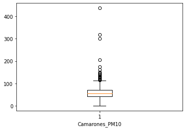

```python
contaminante = "Camarones_PM10"
plt.boxplot(x=camarones_train[~camarones_train.filter(regex=contaminante, axis=1).isna().any(axis=1)][contaminante])
plt.xlabel(contaminante)
plt.show()
```

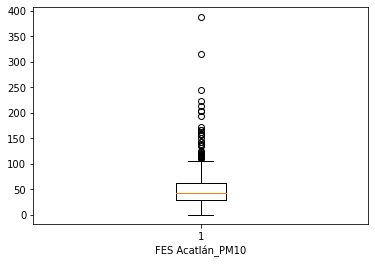

```python
contaminante = "FES Acatlán_PM10"
plt.boxplot(x=camarones_train[~camarones_train.filter(regex=contaminante, axis=1).isna().any(axis=1)][contaminante])
plt.xlabel(contaminante)
plt.show()
```

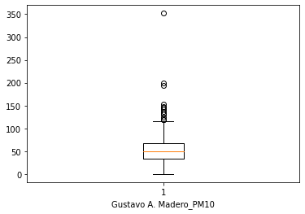

```python
contaminante = "Gustavo A. Madero_PM10"
plt.boxplot(x=camarones_train[~camarones_train.filter(regex=contaminante, axis=1).isna().any(axis=1)][contaminante])
plt.xlabel(contaminante)
plt.show()
```

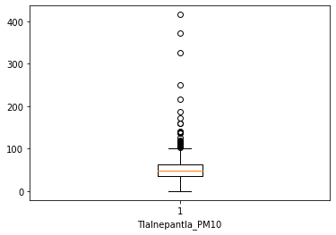

```python
contaminante = "Tlalnepantla_PM10"
plt.boxplot(x=camarones_train[~camarones_train.filter(regex=contaminante, axis=1).isna().any(axis=1)][contaminante])
plt.xlabel(contaminante)
plt.show()
```

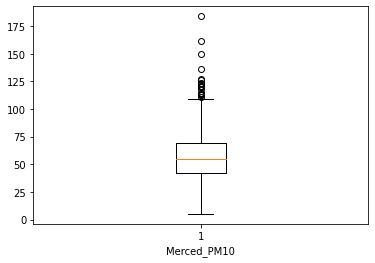

```python
contaminante = "Merced_PM10"
plt.boxplot(x=camarones_train[~camarones_train.filter(regex=contaminante, axis=1).isna().any(axis=1)][contaminante])
plt.xlabel(contaminante)
plt.show()
```

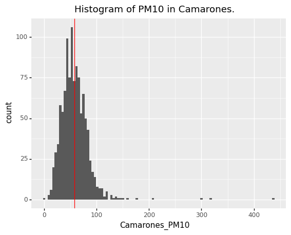

```python
(
    ggplot(camarones_train[["Camarones_PM10"]]) +
    geom_histogram(aes(x="Camarones_PM10"), bins=100) +
    geom_vline(aes(xintercept=camarones_train["Camarones_PM10"].mean()),
                   color="red") +
    labs(title="Histogram of PM10 in Camarones.")
)
```

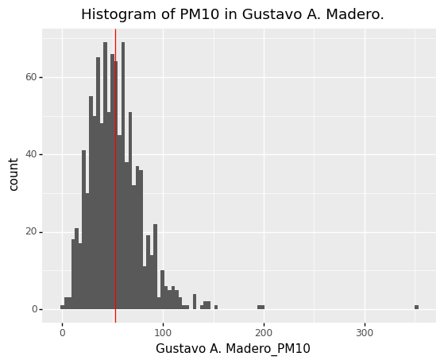

```python
(
    ggplot(camarones_train[["Gustavo A. Madero_PM10"]]) +
    geom_histogram(aes(x="Gustavo A. Madero_PM10"), bins=100) +
    geom_vline(aes(xintercept=camarones_train["Gustavo A. Madero_PM10"].mean()),
                   color="red") +
    labs(title="Histogram of PM10 in Gustavo A. Madero.")
)
```

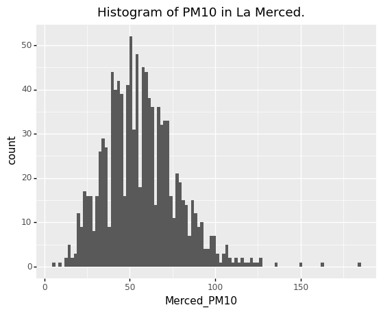

```python
(
    ggplot(camarones_train[["Merced_PM10"]]) +
    geom_histogram(aes(x="Merced_PM10"), bins=100) +
    labs(title="Histogram of PM10 in La Merced.")
)
```

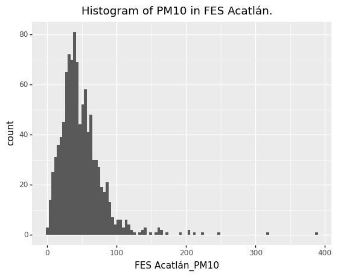

```python
(
    ggplot(camarones_train[["FES Acatlán_PM10"]]) +
    geom_histogram(aes(x="FES Acatlán_PM10"), bins=100) +
    labs(title="Histogram of PM10 in FES Acatlán.")
)
```

#### Comparing Stations

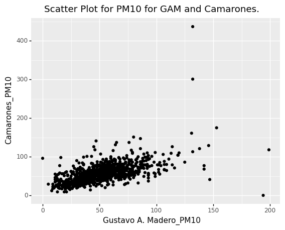

```python
(
    ggplot(camarones_train[~camarones_train.filter(regex=r"PM10", axis=1).isna().any(axis=1)]) +
    geom_point(aes(x="Gustavo A. Madero_PM10", y="Camarones_PM10")) +
    labs(title="Scatter Plot for PM10 for GAM and Camarones.")
)
```

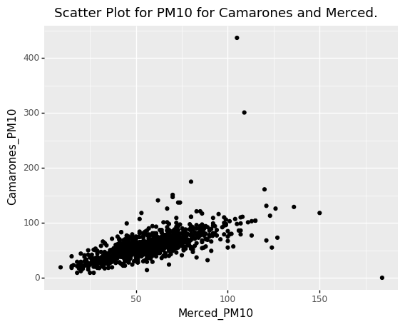

```python
(
    ggplot(camarones_train[~camarones_train.filter(regex=r"PM10", axis=1).isna().any(axis=1)]) +
    geom_point(aes(x="Merced_PM10", y="Camarones_PM10")) +
    labs(title="Scatter Plot for PM10 for Camarones and Merced.")
)
```

```python
corr = camarones_train.filter(like="PM10", axis=1)[~camarones_train.filter(regex=r"PM10", axis=1).isna().any(axis=1)].corr()
corr
```

|  | Camarones_PM10 | FES Acatlán_PM10 | Gustavo A. Madero_PM10 | Merced_PM10 | Tlalnepantla_PM10 |
| --- | --- | --- | --- | --- | --- |
| Camarones_PM10 | 1.000000 | 0.588032 | 0.573777 | 0.642624 | 0.633015 |
| FES Acatlán_PM10 | 0.588032 | 1.000000 | 0.561526 | 0.596102 | 0.755112 |
| Gustavo A. Madero_PM10 | 0.573777 | 0.561526 | 1.000000 | 0.779445 | 0.588039 |
| Merced_PM10 | 0.642624 | 0.596102 | 0.779445 | 1.000000 | 0.599155 |
| Tlalnepantla_PM10 | 0.633015 | 0.755112 | 0.588039 | 0.599155 | 1.000000 |

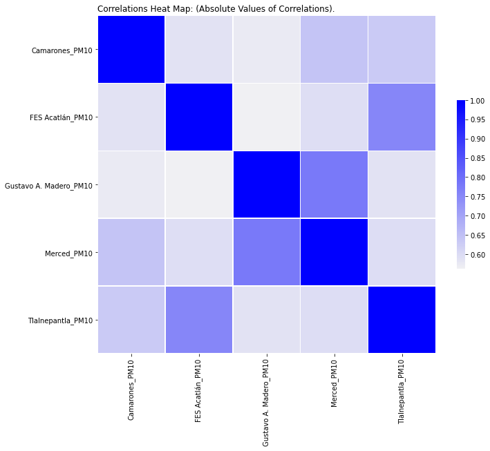

```python
#corr = corr.loc[:, ["PM2.5", "PM10"]]
mask = None
#mask = np.triu(np.ones_like(corr*-1, dtype=bool))

# Set up the matplotlib figure
f, ax = plt.subplots(figsize=(11, 9))

# Generate a custom diverging colormap
#cmap = sns.palettes.blend_palette(["#ffffff", "#000055"],
#                                  n_colors=16,
#                                  as_cmap=True)
cmap = sns.color_palette("light:blue", as_cmap=True)

plt.title("Correlations Heat Map: " +
          "(Absolute Values of Correlations).", loc='left')
# Draw the heatmap with the mask and correct aspect ratio
sns.heatmap(corr, mask=mask, cmap=cmap, #vmax=.3, center=0,
            square=True, linewidths=.5, cbar_kws={"shrink": .5})
#plt.xlabel("Variables Respuesta")
#plt.ylabel("Variables Predictoras")
plt.show()
```

```python
corr = camarones_train.filter(like="Camarones", axis=1)[~camarones_train.filter(regex=r"Camarones", axis=1).isna().any(axis=1)].corr()
corr
```

|  | Camarones_CO | Camarones_NO | Camarones_NO2 | Camarones_NOx | Camarones_O3 | Camarones_PM10 | Camarones_PM2.5 | Camarones_SO2 |
| --- | --- | --- | --- | --- | --- | --- | --- | --- |
| Camarones_CO | 1.000000 | 0.745593 | 0.771172 | 0.839178 | -0.455741 | 0.297277 | 0.425596 | 0.109512 |
| Camarones_NO | 0.745593 | 1.000000 | 0.456594 | 0.965661 | -0.440542 | 0.124081 | 0.200851 | 0.105557 |
| Camarones_NO2 | 0.771172 | 0.456594 | 1.000000 | 0.656534 | -0.554310 | 0.279483 | 0.435905 | 0.160720 |
| Camarones_NOx | 0.839178 | 0.965661 | 0.656534 | 1.000000 | -0.522438 | 0.181161 | 0.288952 | 0.133070 |
| Camarones_O3 | -0.455741 | -0.440542 | -0.554310 | -0.522438 | 1.000000 | 0.030864 | 0.003132 | -0.192407 |
| Camarones_PM10 | 0.297277 | 0.124081 | 0.279483 | 0.181161 | 0.030864 | 1.000000 | 0.610515 | 0.157361 |
| Camarones_PM2.5 | 0.425596 | 0.200851 | 0.435905 | 0.288952 | 0.003132 | 0.610515 | 1.000000 | 0.298078 |
| Camarones_SO2 | 0.109512 | 0.105557 | 0.160720 | 0.133070 | -0.192407 | 0.157361 | 0.298078 | 1.000000 |

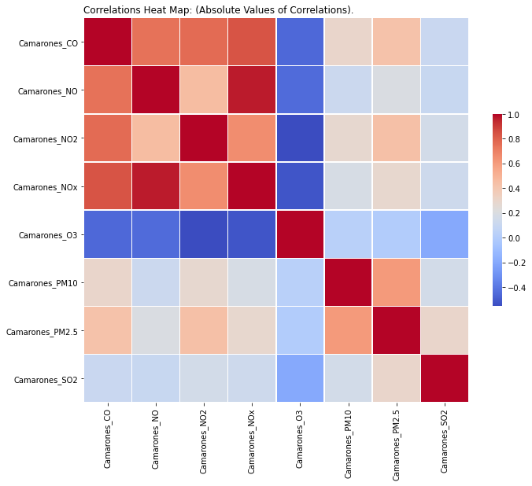

```python
#corr = corr.loc[:, ["PM2.5", "PM10"]]
mask = None
#mask = np.triu(np.ones_like(corr*-1, dtype=bool))

# Set up the matplotlib figure
f, ax = plt.subplots(figsize=(11, 9))

# Generate a custom diverging colormap
#cmap = sns.palettes.blend_palette(["#ffffff", "#000055"],
#                                  n_colors=16,
#                                  as_cmap=True)
#cmap = sns.diverging_palette(250, 20, as_cmap=True)
cmap = sns.color_palette("coolwarm", as_cmap=True)

plt.title("Correlations Heat Map: " +
          "(Absolute Values of Correlations).", loc='left')
# Draw the heatmap with the mask and correct aspect ratio
sns.heatmap(corr, mask=mask, cmap=cmap, #vmax=.3, center=0,
            square=True, linewidths=.5, cbar_kws={"shrink": .5})
#plt.xlabel("Variables Respuesta")
#plt.ylabel("Variables Predictoras")
plt.show()
```

#### PM2.5

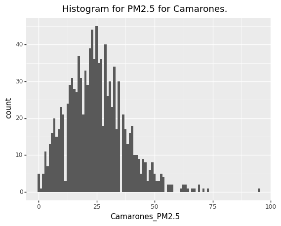

```python
(
    ggplot(camarones_train[["Camarones_PM2.5"]]) +
    geom_histogram(aes(x="Camarones_PM2.5"), bins=100) +
    labs(title="Histogram for PM2.5 for Camarones.")
)
```

## Regresión Lineal

Removemos observaciones incompletas para realizar la regresión.

```python
Y_train = camarones_train["Camarones_PM10"]
Y_test  = camarones_test["Camarones_PM10"]
X_train = camarones_train.filter(regex=r"^(?!Camarones_PM10|Fecha)", axis=1)
X_test = camarones_test.filter(regex=r"^(?!Camarones_PM10|Fecha)", axis=1)

X_train = camarones_train.filter(regex="(Merced|Tlalnepantla)")
X_test  = camarones_test.filter(regex="(Merced|Tlalnepantla)")

## guardar los parquet para correr Stan en R
camarones_train.to_parquet("data/camarones_train.parquet")
camarones_test.to_parquet("data/camarones_test.parquet")

### Código para filtrar solo las columnas con PM10
### Es decir, estaciones que tienen el contaminante PM10
X_test = X_test.filter(regex=r"PM10", axis=1)
X_train = X_train.filter(regex=r"PM10", axis=1)

## Removemos observaciones incompletas
X_train = X_train[~camarones_train.filter(regex=r"PM10", axis=1).isna().any(axis=1)]
X_test = X_test[~camarones_test.filter(regex=r"PM10", axis=1).isna().any(axis=1)]
Y_train = Y_train[~camarones_train.filter(regex=r"PM10", axis=1).isna().any(axis=1)]
Y_test = Y_test[~camarones_test.filter(regex=r"PM10", axis=1).isna().any(axis=1)]
```

```python
reg = LinearRegression(n_jobs=8).fit(X_train, Y_train)
Yhat_train_lin = reg.predict(X_train)
Yhat_test_lin = reg.predict(X_test)
```

```python
X_train.columns
```

```
Index(['Merced_PM10', 'Tlalnepantla_PM10'], dtype='object')
```

```python
reg.coef_
```

```
array([0.53026139, 0.36873538])
```

```python
reg.intercept_
```

```
8.861413306258605
```

```python
r2_score(Y_train, Yhat_train_lin)
```

```
0.5089006183870153
```

```python
r2_score(Y_test, Yhat_test_lin)
```

```
-0.4162199659052408
```

```python
mean_squared_error(Y_train, Yhat_train_lin)
```

```
371.5820988359095
```

```python
mean_squared_error(Y_test, Yhat_test_lin)
```

```
845.7794576326868
```

```python
mean_absolute_error(Y_train, Yhat_train_lin)
```

```
10.931473014049846
```

```python
mean_absolute_error(Y_test, Yhat_test_lin)
```

```
13.047752185462492
```

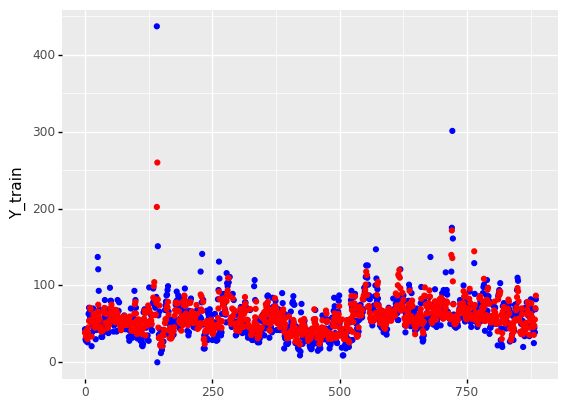

```python
(
    ggplot(pd.DataFrame({
        "Y_train": Y_train,
        "Yhat_train": Yhat_train_lin
    })) +
    geom_point(aes(x=range(0, Y_train.shape[0]), y="Y_train"), color='blue') +
    geom_point(aes(x=range(0, Y_train.shape[0]), y="Yhat_train"), color='red')
)
```

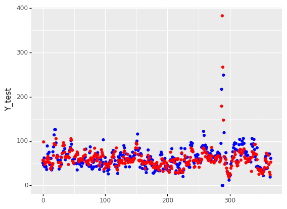

```python
(
    ggplot(pd.DataFrame({
        "Y_test": Y_test,
        "Yhat_test": Yhat_test_lin
    })) +
    geom_point(aes(x=range(0, Y_test.shape[0]), y="Y_test"), color='blue') +
    geom_point(aes(x=range(0, Y_test.shape[0]), y="Yhat_test"), color='red')
)
```

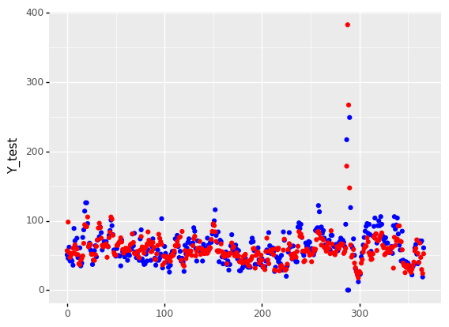

```python
(
    ggplot(pd.DataFrame({
        "Y_test": Y_test,
        "Yhat_test": Yhat_test_lin
    })) +
    geom_point(aes(x=range(0, Y_test.shape[0]), y="Y_test"), color='blue') +
    geom_point(aes(x=range(0, Y_test.shape[0]), y="Yhat_test"), color='red')
)
```

## Lasso

```python
Y_train = camarones_train["Camarones_PM10"]
Y_test  = camarones_test["Camarones_PM10"]
X_train = camarones_train.filter(regex=r"^(?!Camarones_PM10|Fecha)", axis=1)
X_test = camarones_test.filter(regex=r"^(?!Camarones_PM10|Fecha)", axis=1)

### Código para filtrar solo las columnas con PM10
### Es decir, estaciones que tienen el contaminante PM10
X_test = X_test.filter(regex=r"PM10", axis=1)
X_train = X_train.filter(regex=r"PM10", axis=1)

## Removemos observaciones incompletas
X_train = X_train[~camarones_train.filter(regex=r"PM10", axis=1).isna().any(axis=1)]
X_test = X_test[~camarones_test.filter(regex=r"PM10", axis=1).isna().any(axis=1)]
Y_train = Y_train[~camarones_train.filter(regex=r"PM10", axis=1).isna().any(axis=1)]
Y_test = Y_test[~camarones_test.filter(regex=r"PM10", axis=1).isna().any(axis=1)]

reg = Lasso().fit(X_train, Y_train)
Yhat_train_lasso = reg.predict(X_train)
Yhat_test_lasso = reg.predict(X_test)

reg.coef_
```

```
array([0.10494418, 0.0689564 , 0.43803925, 0.28309869])
```

```python
reg.intercept_
```

```
9.793830115973797
```

```python
r2_score(Y_train, Yhat_train_lasso)
```

```
0.5169119069776114
```

```python
r2_score(Y_test, Yhat_test_lasso)
```

```
-0.11224862731990415
```

```python
mean_squared_error(Y_train, Yhat_train_lasso)
```

```
365.52049187746337
```

```python
mean_squared_error(Y_test, Yhat_test_lasso)
```

```
664.2450067183082
```

```python
mean_absolute_error(Y_train, Yhat_train_lasso)
```

```
10.791035566246128
```

```python
mean_absolute_error(Y_test, Yhat_test_lasso)
```

```
12.489847967051261
```

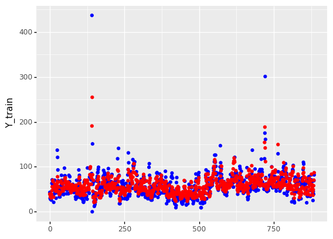

```python
(
    ggplot(pd.DataFrame({
        "Y_train": Y_train,
        "Yhat_train": Yhat_train_lasso
    })) +
    geom_point(aes(x=range(0, Y_train.shape[0]), y="Y_train"), color='blue') +
    geom_point(aes(x=range(0, Y_train.shape[0]), y="Yhat_train"), color='red')
)
```

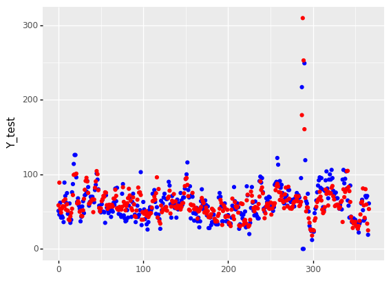

```python
(
    ggplot(pd.DataFrame({
        "Y_test": Y_test,
        "Yhat_test": Yhat_test_lasso
    })) +
    geom_point(aes(x=range(0, Y_test.shape[0]), y="Y_test"), color='blue') +
    geom_point(aes(x=range(0, Y_test.shape[0]), y="Yhat_test"), color='red')
)
```

## Mean

```python
Yhat_train_mean = X_train.mean(axis=1)
Yhat_test_mean = X_test.mean(axis=1)
```

```python
mean_squared_error(Y_train, Yhat_train_mean)
```

```
422.1441318590655
```

```python
mean_squared_error(Y_test, Yhat_test_mean)
```

```
579.0378415931376
```

```python
mean_absolute_error(Y_train, Yhat_train_mean)
```

```
12.22969669074124
```

```python
mean_absolute_error(Y_test, Yhat_test_mean)
```

```
13.812958507896164
```

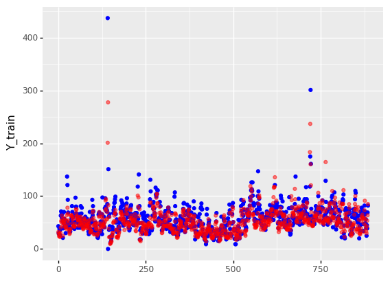

```python
(
    ggplot(pd.DataFrame({
        "Y_train": Y_train,
        "Yhat_train": Yhat_train_mean
    })) +
    geom_point(aes(x=range(0, Y_train.shape[0]), y="Y_train"),
               color='blue') +
    geom_point(aes(x=range(0, Y_train.shape[0]), y="Yhat_train"),
               color='red', alpha=.5)
)
```

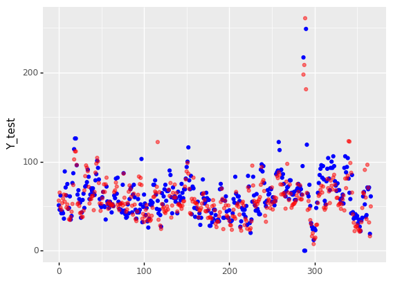

```python
(
    ggplot(pd.DataFrame({
        "Y_train": Y_test,
        "Yhat_train": Yhat_test_mean
    })) +
    geom_point(aes(x=range(0, Y_test.shape[0]), y="Y_test"),
               color='blue') +
    geom_point(aes(x=range(0, Y_test.shape[0]), y="Yhat_train"),
               color='red', alpha=.5)
)
```

## Generalized Linear Models: GLM

```python
from sklearn.linear_model import PoissonRegressor
reg = PoissonRegressor(alpha=1e3)
reg_fit = reg.fit(X_train, Y_train)
```

```python
Yhat_train_glm = reg_fit.predict(X_train)
(Yhat_train_glm.shape, Y_train.shape)
```

```
((886,), (886,))
```

```python
Yhat_test_glm = reg_fit.predict(X_test)
(Yhat_test_glm.shape, Y_test.shape)
```

```
((367,), (367,))
```

```python
mean_squared_error(Yhat_train_glm
                   , Y_train)
```

```
562.8146939425658
```

```python
mean_squared_error(Yhat_test_glm, Y_test)
```

```
7875.849124574941
```

```python
mean_absolute_error(Yhat_train_glm, Y_train)
```

```
12.15806111211628
```

```python
mean_absolute_error(Yhat_test_glm, Y_test)
```

```
17.957714790509712
```

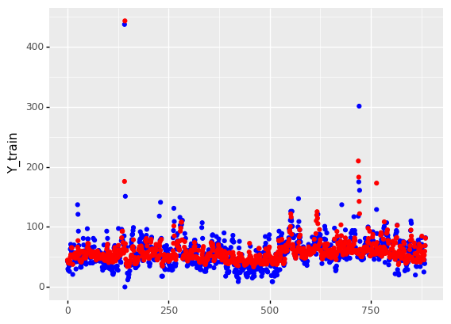

```python
(
    ggplot(pd.DataFrame({
        "Y_train": Y_train.reset_index(drop=True),
        "Yhat_train": Yhat_train_glm
    })) +
    geom_point(aes(x=range(0, Y_train.shape[0]), y="Y_train"), color='blue') +
    geom_point(aes(x=range(0, Y_train.shape[0]), y="Yhat_train"), color='red')
)
```

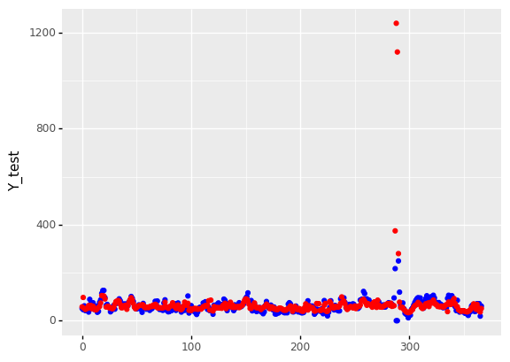

```python
(
    ggplot(pd.DataFrame({
        "Y_test": Y_test,
        "Yhat_test": Yhat_test_glm
    })) +
    geom_point(aes(x=range(0, Y_test.shape[0]), y="Y_test"), color='blue') +
    geom_point(aes(x=range(0, Y_test.shape[0]), y="Yhat_test"), color='red')
)
```

## K-Nearest Neighbors

```python
from sklearn.neighbors import KNeighborsRegressor
knn = KNeighborsRegressor(n_neighbors=20, p=1)
knn_fit = knn.fit(X_train, Y_train)
```

```python
Yhat_train_knn = knn_fit.predict(X_train)
(Yhat_train_knn.shape, Y_train.shape)
```

```
((886,), (886,))
```

```python
Yhat_test_knn = knn_fit.predict(X_test)
(Yhat_test_knn.shape, Y_test.shape)
```

```
((367,), (367,))
```

```python
mean_squared_error(Yhat_train_knn,
                   Y_train)
```

```
347.29259904240126
```

```python
mean_squared_error(Yhat_test_knn, Y_test)
```

```
325.37804270928683
```

```python
mean_absolute_error(Yhat_train_knn, Y_train)
```

```
10.748652093480683
```

```python
mean_absolute_error(Yhat_test_knn, Y_test)
```

```
11.676590585214306
```

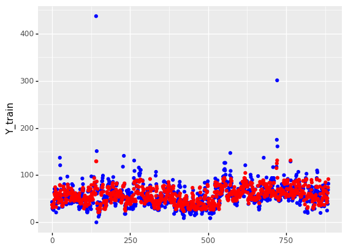

```python
(
    ggplot(pd.DataFrame({
        "Y_train": Y_train.reset_index(drop=True),
        "Yhat_train": Yhat_train_knn
    })) +
    geom_point(aes(x=range(0, Y_train.shape[0]), y="Y_train"), color='blue') +
    geom_point(aes(x=range(0, Y_train.shape[0]), y="Yhat_train"), color='red')
)
```

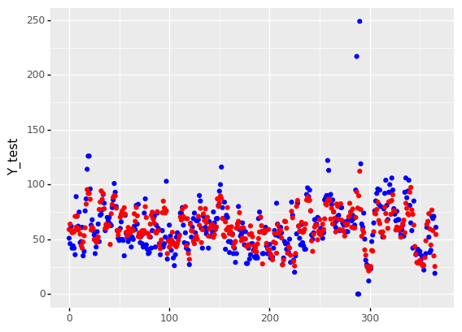

```python
(
    ggplot(pd.DataFrame({
        "Y_test": Y_test,
        "Yhat_test": Yhat_test_knn
    })) +
    geom_point(aes(x=range(0, Y_test.shape[0]), y="Y_test"), color='blue') +
    geom_point(aes(x=range(0, Y_test.shape[0]), y="Yhat_test"), color='red')
)
```

## Evaluation

```python
df = pd.DataFrame({
        "Y_test": Y_test.reset_index(drop=True),
        #"Yhat_test": Yhat_test_stan
    })
df = df[~df.isnull().any(axis=1)]
df2 = pd.DataFrame({
    "Model": [
        "1.2 Regresión Lineal",
        "1.3 Lasso",
        #"1.4 Stan",
        "1.5 Media",
        "1.6 GLM",
        "1.7 KNN"
    ],
    "MSE (Train Set)": [
        mean_squared_error(Y_train, Yhat_train_lin),
        mean_squared_error(Y_train, Yhat_train_lasso),
        #mean_squared_error(Y_train, Yhat_train_stan),
        mean_squared_error(Y_train, Yhat_train_mean),
        mean_squared_error(Y_train, Yhat_train_glm),
        mean_squared_error(Y_train, Yhat_train_knn),
    ],
    "MAE (Train Set)": [
        mean_absolute_error(Y_train, Yhat_train_lin),
        mean_absolute_error(Y_train, Yhat_train_lasso),
        #mean_absolute_error(Y_train, Yhat_train_stan),
        mean_absolute_error(Y_train, Yhat_train_mean),
        mean_absolute_error(Y_train, Yhat_train_glm),
        mean_absolute_error(Y_train, Yhat_train_knn),
    ],
    "MSE (Test Set)": [
        mean_squared_error(Y_test, Yhat_test_lin),
        mean_squared_error(Y_test, Yhat_test_lasso),
        #mean_squared_error(df[["Y_test"]], df[["Yhat_test"]]),
        mean_squared_error(Y_test, Yhat_test_mean),
        mean_squared_error(Y_test, Yhat_test_glm),
        mean_squared_error(Y_test, Yhat_test_knn),
    ],
    "MAE (Test Set)": [
        mean_absolute_error(Y_test, Yhat_test_lin),
        mean_absolute_error(Y_test, Yhat_test_lasso),
        #mean_absolute_error(df[["Y_test"]], df[["Yhat_test"]]),
        mean_absolute_error(Y_test, Yhat_test_mean),
        mean_absolute_error(Y_test, Yhat_test_glm),
        mean_absolute_error(Y_test, Yhat_test_knn),
    ]
    })
df2.sort_values(by="MSE (Test Set)")
```

|  | Model | MSE (Train Set) | MAE (Train Set) | MSE (Test Set) | MAE (Test Set) |
| --- | --- | --- | --- | --- | --- |
| 4 | 1.7 KNN | 347.292599 | 10.748652 | 325.378043 | 11.676591 |
| 2 | 1.5 Media | 422.144132 | 12.229697 | 579.037842 | 13.812959 |
| 1 | 1.3 Lasso | 365.520492 | 10.791036 | 664.245007 | 12.489848 |
| 0 | 1.2 Regresión Lineal | 371.582099 | 10.931473 | 845.779458 | 13.047752 |
| 3 | 1.6 GLM | 562.814694 | 12.158061 | 7875.849125 | 17.957715 |

## Early Conclusions

Given that we all further treatment to use the data should be in a sequential fashion, ie as timeseries: we found that linear interpolation is adequate.

Then in the next section we are detailing it.

## Interpolation

We found in the EDA and in previous sections that Merced has similar data as Camarones, and it has fewer incomplete observations (missing data).

```python
merced = dsinaica.filter(regex='^Merced_').describe()
dsinaica.shape[0] - merced.iloc[0]
```

```
Merced_CO        70.0
Merced_NO       971.0
Merced_NO2       88.0
Merced_NOx       88.0
Merced_O3        82.0
Merced_PM10      31.0
Merced_PM2.5     36.0
Merced_SO2       64.0
Name: count, dtype: float64
```

Camarones has more incomplete observations:

```python
camarones = dsinaica.filter(regex='^Camarones_').describe()
dsinaica.shape[0] - camarones.iloc[0]
```

```
Camarones_CO       111.0
Camarones_NO       125.0
Camarones_NO2      125.0
Camarones_NOx      310.0
Camarones_O3       119.0
Camarones_PM10     603.0
Camarones_PM2.5    587.0
Camarones_SO2      162.0
Name: count, dtype: float64
```

Using those results we create a new dataframe with those imputations.

The data in the dataframe have the following columns (vars) in the following manner:

- CO: Merced
- NO: Camarones
- NO2: Merced
- NOx: Merced
- O3: Merced
- PM10: Merced
- PM2.5: Merced

We used a lag to use the missing hours and found these gaps in the time line:

```python
sinaica_imputated = pd.DataFrame(dsinaica["Fecha"])
sinaica_imputated["CO"] = dsinaica["Merced_CO"]
sinaica_imputated["NO"] = dsinaica["Camarones_NO"]
sinaica_imputated["NO2"] = dsinaica["Merced_NO2"]
sinaica_imputated["NOx"] = dsinaica["Merced_NOx"]
sinaica_imputated["O3"] = dsinaica["Merced_O3"]
sinaica_imputated["PM10"] = dsinaica["Merced_PM10"]
sinaica_imputated["PM2.5"] = dsinaica["Merced_PM2.5"]
sinaica_imputated["SO2"] = dsinaica["Merced_SO2"]
sinaica_imputated["datetime"] = pd.to_datetime(sinaica_imputated["Fecha"])
sinaica_imputated = sinaica_imputated[~sinaica_imputated.isna().any(axis=1)]
sinaica_imputated["year"] = [dt.year for dt in sinaica_imputated.datetime]
sinaica_imputated["month"] = [dt.month for dt in sinaica_imputated.datetime]
sinaica_imputated["day"] = [dt.day for dt in sinaica_imputated.datetime]
sinaica_imputated["hour"] = [dt.hour for dt in sinaica_imputated.datetime]
sinaica_imputated["datetime-1"] = sinaica_imputated["datetime"].shift(1)
sinaica_imputated["delta"] = sinaica_imputated["datetime"] - sinaica_imputated["datetime-1"]
sinaica_imputated["delta"] = (sinaica_imputated["delta"].dt.seconds // 60**2)
sinaica_imputated["imputated"] = False
sinaica_imputated = sinaica_imputated[~sinaica_imputated.isna().any(axis=1)]
sinaica_imputated.reset_index(drop=True, inplace=True)
sinaica_imputated
```

|  | Fecha | CO | NO | NO2 | NOx | O3 | PM10 | PM2.5 | SO2 | datetime | year | month | day | hour | datetime-1 | delta | imputated |
| --- | --- | --- | --- | --- | --- | --- | --- | --- | --- | --- | --- | --- | --- | --- | --- | --- | --- |
| 0 | 2021-01-01 02:00:00 | 1.100000 | 0.013000 | 0.032000 | 0.039000 | 0.004000 | 37.000000 | 24.000000 | 0.003000 | 2021-01-01 02:00:00 | 2021 | 1 | 1 | 2 | 2021-01-01 00:00:00 | 2.0 | False |
| 1 | 2021-01-01 03:00:00 | 1.200000 | 0.031000 | 0.033000 | 0.043000 | 0.001000 | 49.000000 | 39.000000 | 0.003000 | 2021-01-01 03:00:00 | 2021 | 1 | 1 | 3 | 2021-01-01 02:00:00 | 1.0 | False |
| 2 | 2021-01-01 04:00:00 | 1.200000 | 0.005000 | 0.031000 | 0.039000 | 0.002000 | 80.000000 | 65.000000 | 0.003000 | 2021-01-01 04:00:00 | 2021 | 1 | 1 | 4 | 2021-01-01 03:00:00 | 1.0 | False |
| 3 | 2021-01-01 05:00:00 | 1.200000 | 0.016000 | 0.028000 | 0.036000 | 0.002000 | 89.000000 | 75.000000 | 0.003000 | 2021-01-01 05:00:00 | 2021 | 1 | 1 | 5 | 2021-01-01 04:00:00 | 1.0 | False |
| 4 | 2021-01-01 06:00:00 | 1.400000 | 0.024000 | 0.029000 | 0.060000 | 0.001000 | 75.000000 | 64.000000 | 0.003000 | 2021-01-01 06:00:00 | 2021 | 1 | 1 | 6 | 2021-01-01 05:00:00 | 1.0 | False |
| ... | ... | ... | ... | ... | ... | ... | ... | ... | ... | ... | ... | ... | ... | ... | ... | ... | ... |
| 2129 | 2021-10-04 00:00:00 | 0.545833 | 0.008292 | 0.019083 | 0.026875 | 0.015833 | 11.826087 | 7.913043 | 0.000750 | 2021-10-04 00:00:00 | 2021 | 10 | 4 | 0 | 2021-10-03 00:00:00 | 0.0 | False |
| 2130 | 2021-10-05 00:00:00 | 0.563158 | 0.010000 | 0.019722 | 0.030500 | 0.012278 | 11.090909 | 6.772727 | 0.000556 | 2021-10-05 00:00:00 | 2021 | 10 | 5 | 0 | 2021-10-04 00:00:00 | 0.0 | False |
| 2131 | 2021-10-06 00:00:00 | 0.672222 | 0.007571 | 0.026111 | 0.035611 | 0.011000 | 18.722222 | 11.833333 | 0.000111 | 2021-10-06 00:00:00 | 2021 | 10 | 6 | 0 | 2021-10-05 00:00:00 | 0.0 | False |
| 2132 | 2021-10-07 00:00:00 | 0.713636 | 0.011565 | 0.028636 | 0.040318 | 0.017909 | 26.772727 | 17.000000 | 0.001045 | 2021-10-07 00:00:00 | 2021 | 10 | 7 | 0 | 2021-10-06 00:00:00 | 0.0 | False |
| 2133 | 2021-10-08 00:00:00 | 0.758824 | 0.023778 | 0.029412 | 0.050588 | 0.017941 | 29.000000 | 17.705882 | 0.008176 | 2021-10-08 00:00:00 | 2021 | 10 | 8 | 0 | 2021-10-07 00:00:00 | 0.0 | False |

2134 rows × 17 columns

These are the missing gaps:

```python
(sinaica_imputated[sinaica_imputated.delta > 2].
 sort_values("delta", ascending=False)
 [["Fecha", "delta"]].
 reset_index(drop=True).
 rename(columns={"delta": "Missing observations",
                 "Fecha": "Date"
                }).
 head(10)
)
```

|  | Date | Missing observations |
| --- | --- | --- |
| 0 | 2021-01-09 13:00:00 | 13.0 |
| 1 | 2021-03-11 23:00:00 | 12.0 |
| 2 | 2021-03-17 09:00:00 | 9.0 |
| 3 | 2021-03-17 00:00:00 | 8.0 |
| 4 | 2021-01-21 23:00:00 | 8.0 |
| 5 | 2021-02-26 08:00:00 | 8.0 |
| 6 | 2021-02-26 00:00:00 | 7.0 |
| 7 | 2021-02-22 15:00:00 | 6.0 |
| 8 | 2021-02-26 14:00:00 | 6.0 |
| 9 | 2021-01-01 18:00:00 | 5.0 |

Realizamos una interpolación quedando los datos así:

```python
%%time

def interpolate_missing(df, idx, hours=1):
    """
    Function to interpolate missing.

    examples
        airdata2 = interpolate_missing(airdata, idx = airdata[airdata.delta > 100].index[0])
        airdata2 = interpolate_missing(airdata, 194044)
    """
    np.random.seed(175904)
    df_prev = df.loc[idx - 1]

    a  = df_prev
    b  = df.loc[idx]

    offsetEnd = pd.offsets.Hour(1) # remove closed form

    out = {}
    out["datetime"] = pd.date_range(a["datetime"] + offsetEnd,
                             b["datetime"] - offsetEnd,
                             freq='1h')
    out["datetime"] = out["datetime"].set_names("datetime")

    for v in ['CO', 'NO', 'NO2', 'NOx', 'O3', 'PM10', 'PM2.5', 'SO2']:
        i = [i+1 for i, d in enumerate(out["datetime"])]
        m = (b[v] - a[v])/len(out["datetime"])
        sd = 0.7*np.std(df_prev[v])
        rnds = np.random.normal(-sd, sd, len(out["datetime"]))
        #rnds = np.random.uniform(-2*np.pi, 2*np.pi, len(out["datetime"]))
        #rnds = np.cos(rnds) * sd
        out[v] = [m*j + a[v] + rnds[j-1] for j in i]
        #out[v] = [m*j  b[v] + rnds[j-1] for j in i]

    #out["iaqAccuracy"] = 1

    idf = pd.DataFrame(out)
    reorder_columns = [col for col in out.keys() if col != 'datetime']
    reorder_columns.append("datetime")
    idf = idf.reindex(columns=reorder_columns)
    #print(reorder_columns)

    idf["year"] = [dt.year for dt in idf["datetime"]]
    idf["month"] = [dt.month for dt in idf["datetime"]]
    idf["day"] = [dt.day for dt in idf["datetime"]]
    idf["hour"] = [dt.hour for dt in idf["datetime"]]
    #idf["minute"] = [dt.minute for dt in idf["datetime"]]
    idf["imputated"] = True

    # original dataframe
    idf = pd.concat([df.reset_index(drop=True), idf.reset_index(drop=True)])
    idf.sort_values("datetime", inplace=True)
    idf.reset_index(inplace=True, drop=True)

    idf["datetime-1"] = idf["datetime"].shift(1)
    idf["delta"] = idf["datetime"] - idf["datetime-1"]
    idf["delta"] = idf["delta"].dt.seconds // 60**2

    return  idf

sinaica2 = sinaica_imputated.copy()
#sinaica2 = interpolate_missing(sinaica2, 1600)
#sinaica2[sinaica2.datetime >= pd.to_datetime('2021-03-15 09:00:00')][sinaica2.datetime <= pd.to_datetime('2021-03-17 11:00:00')]
imputation_list = [x for x in reversed(sinaica_imputated.delta[sinaica_imputated.delta > 1].index)]
sinaica2 = sinaica_imputated.copy()
for x in imputation_list:
  try:
    sinaica2 = interpolate_missing(sinaica2, x)
  except:
    print(f"Skipping {x}")
sinaica2 = sinaica2.loc[1:].reset_index(drop=True)
#sinaica2
```

```
Skipping 0
CPU times: user 759 ms, sys: 2.96 ms, total: 762 ms
Wall time: 762 ms
```

```python
airdata = pd.read_pickle("data/airdata/air-imputated.pickle.gz")
#airdata = airdata.groupby(["year", "month", "day", "hour"], as_index=False)
#airdata = airdata.aggregate(np.mean)
airdata = airdata[[c for c in airdata.columns if c not in ["iaqAccuracy", "year"]]]
#airdata["IAQ"] = airdata[["IAQ"]].round(0).astype('int64')
airdata["minute"] = airdata[["IAQ"]].round(0).astype('int64')
airdata = airdata[["datetime", "month", "day", "hour", "minute", "temperature", "pressure", "humidity",
                   "gasResistance", "IAQ"]].copy()
sinaica3 = sinaica2[[c for c in sinaica2.columns if c not in ["datetime-1", "delta",
                                                              "imputated", "year",
                                                              "datetime", "Fecha"]]]
sinaica3 = pd.merge(sinaica3, airdata, on=['month', 'day', 'hour'], how="left")
sinaica3 = sinaica3.loc[~sinaica3.isna().any(axis=1)]
sinaica3
```

|  | CO | NO | NO2 | NOx | O3 | PM10 | PM2.5 | SO2 | month | day | hour | datetime | minute | temperature | pressure | humidity | gasResistance | IAQ |
| --- | --- | --- | --- | --- | --- | --- | --- | --- | --- | --- | --- | --- | --- | --- | --- | --- | --- | --- |
| 987 | 2.200000 | 0.205000 | 0.031000 | 0.207000 | 0.002000 | 45.000000 | 22.000000 | 0.004000 | 2 | 12 | 6 | 2021-02-12 06:05:35.846304417 | 35.0 | 21.51 | 777.41 | 44.04 | 152149.0 | 34.7 |
| 988 | 2.200000 | 0.205000 | 0.031000 | 0.207000 | 0.002000 | 45.000000 | 22.000000 | 0.004000 | 2 | 12 | 6 | 2021-02-12 06:05:38.837326527 | 34.0 | 21.51 | 777.41 | 43.98 | 152841.0 | 33.6 |
| 989 | 2.200000 | 0.205000 | 0.031000 | 0.207000 | 0.002000 | 45.000000 | 22.000000 | 0.004000 | 2 | 12 | 6 | 2021-02-12 06:05:47.812360048 | 32.0 | 21.54 | 777.41 | 43.73 | 153259.0 | 31.5 |
| 990 | 2.200000 | 0.205000 | 0.031000 | 0.207000 | 0.002000 | 45.000000 | 22.000000 | 0.004000 | 2 | 12 | 6 | 2021-02-12 06:05:50.803695202 | 32.0 | 21.53 | 777.41 | 43.70 | 152841.0 | 31.5 |
| 991 | 2.200000 | 0.205000 | 0.031000 | 0.207000 | 0.002000 | 45.000000 | 22.000000 | 0.004000 | 2 | 12 | 6 | 2021-02-12 06:05:53.795462847 | 30.0 | 21.52 | 777.41 | 43.70 | 153399.0 | 30.2 |
| ... | ... | ... | ... | ... | ... | ... | ... | ... | ... | ... | ... | ... | ... | ... | ... | ... | ... | ... |
| 1582081 | 0.765217 | 0.009174 | 0.027826 | 0.039043 | 0.015304 | 20.304348 | 16.391304 | 0.001304 | 9 | 18 | 0 | 2021-09-18 00:59:47.142104626 | 138.0 | 26.00 | 782.92 | 56.34 | 916837.0 | 138.2 |
| 1582082 | 0.765217 | 0.009174 | 0.027826 | 0.039043 | 0.015304 | 20.304348 | 16.391304 | 0.001304 | 9 | 18 | 0 | 2021-09-18 00:59:50.136709690 | 138.0 | 26.00 | 782.92 | 56.33 | 917462.0 | 137.7 |
| 1582083 | 0.765217 | 0.009174 | 0.027826 | 0.039043 | 0.015304 | 20.304348 | 16.391304 | 0.001304 | 9 | 18 | 0 | 2021-09-18 00:59:53.131285429 | 138.0 | 26.00 | 782.90 | 56.34 | 916837.0 | 137.6 |
| 1582084 | 0.765217 | 0.009174 | 0.027826 | 0.039043 | 0.015304 | 20.304348 | 16.391304 | 0.001304 | 9 | 18 | 0 | 2021-09-18 00:59:56.125959396 | 136.0 | 26.00 | 782.92 | 56.35 | 921233.0 | 136.0 |
| 1582085 | 0.765217 | 0.009174 | 0.027826 | 0.039043 | 0.015304 | 20.304348 | 16.391304 | 0.001304 | 9 | 18 | 0 | 2021-09-18 00:59:59.120573282 | 134.0 | 25.99 | 782.92 | 56.35 | 922497.0 | 134.5 |

1581099 rows × 18 columns

```python
sinaica3.to_pickle("data/sinaica/sinaica-imputated.pickle.gz")
```

We have imputated successfully all our data frame.

```python
(sinaica2[sinaica2.delta > 2].
 sort_values("delta", ascending=False)
 [["Fecha", "delta"]].
 reset_index(drop=True).
 rename(columns={"delta": "Missing DAta", 'Fecha': 'Date'}).
 head(10)
)
```

|  | Date | Missing DAta |
| --- | --- | --- |

We recognize this might not be the best method, but we can explore more imputation methods on timeseries modeling.

## References

- https://scikit-learn.org/stable/modules/linear_model.html#generalized-linear-regression
- https://pythonhealthcare.org/2018/05/03/81-distribution-fitting-to-data/
- https://medium.com/@amirarsalan.rajabi/distribution-fitting-with-python-scipy-bb70a42c0aed
- https://scikit-learn.org/stable/modules/generated/sklearn.neighbors.KernelDensity.html?highlight=kernel%20density#sklearn.neighbors.KernelDensity